# INN Hotels Project

# Building a Decision Tree model

```python
X1 = df2.drop(['booking_status'], axis = 1)
Y1 = df2["booking_status"]
```

```python
X1 = pd.get_dummies(X1,
    columns=X1.select_dtypes(include=["object", "category"]).columns.tolist(),
    drop_first=True) #creating dummy variables
```

```python
X1.info()
```

```
<class 'pandas.core.frame.DataFrame'>
RangeIndex: 36275 entries, 0 to 36274
Data columns (total 27 columns):
 #   Column                             Non-Null Count  Dtype
---  ------                             --------------  -----
 0   no_of_adults                       36275 non-null  int64
 1   no_of_children                     36275 non-null  int64
 2   no_of_weekend_nights               36275 non-null  float64
 3   no_of_week_nights                  36275 non-null  float64
 4   required_car_parking_space         36275 non-null  int64
 5   lead_time                          36275 non-null  float64
 6   arrival_year                       36275 non-null  int64
 7   arrival_month                      36275 non-null  int64
 8   arrival_date                       36275 non-null  int64
 9   repeated_guest                     36275 non-null  int64
```

[output cut: 19 more lines]

```python
x1_train, x1_test, y1_train, y1_test = train_test_split(X1, Y1, test_size = .3, random_state = 1)
```

```python
dTree = DecisionTreeClassifier(random_state=1)
dTree.fit(x1_train, y1_train)
```

```
DecisionTreeClassifier(random_state=1)
```

## Functions to check performance on decision tree models

```python
def model_performance_classification_sklearn(model, predictors, target):
    """
    Function to compute different metrics to check classification model performance

    model: classifier
    predictors: independent variables
    target: dependent variable
    """

    # predicting using the independent variables
    pred = model.predict(predictors)

    acc = accuracy_score(target, pred)  # to compute Accuracy
    recall = recall_score(target, pred)  # to compute Recall
    precision = precision_score(target, pred)  # to compute Precision
    f1 = f1_score(target, pred)  # to compute F1-score

    # creating a dataframe of metrics
    df_perf = pd.DataFrame(
        {"Accuracy": acc, "Recall": recall, "Precision": precision, "F1": f1,},
        index=[0],
    )

    return df_perf
```

```python
def confusion_matrix_sklearn(model, predictors, target):
    """
    To plot the confusion_matrix with percentages

    model: classifier
    predictors: independent variables
    target: dependent variable
    """
    y_pred = model.predict(predictors)
    cm = confusion_matrix(target, y_pred)
    labels = np.asarray(
        [
            ["{0:0.0f}".format(item) + "\n{0:.2%}".format(item / cm.flatten().sum())]
            for item in cm.flatten()
        ]
    ).reshape(2, 2)

    plt.figure(figsize=(6, 4))
    sns.heatmap(cm, annot=labels, fmt="")
    plt.ylabel("True label")
    plt.xlabel("Predicted label")
```

```python
decision_tree_perf_train = model_performance_classification_sklearn(dTree, x1_train, y1_train)

decision_tree_perf_train
```

|  | Accuracy | Recall | Precision | F1 |
| --- | --- | --- | --- | --- |
| 0 | 0.99421 | 0.98661 | 0.99578 | 0.99117 |

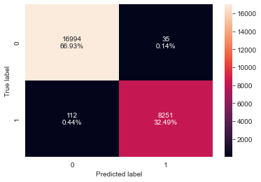

```python
confusion_matrix_sklearn(dTree, x1_train, y1_train)
```

```python
decision_tree_perf_test = model_performance_classification_sklearn(dTree, x1_test, y1_test)

decision_tree_perf_test
```

|  | Accuracy | Recall | Precision | F1 |
| --- | --- | --- | --- | --- |
| 0 | 0.86961 | 0.80806 | 0.79298 | 0.80045 |

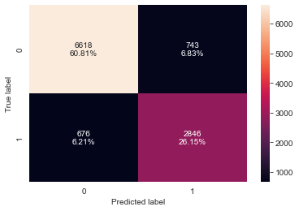

```python
confusion_matrix_sklearn(dTree, x1_test, y1_test)
```

# Do we need to prune the tree?

Yes, we should absolutely do some pruning on this decision tree. The accuracy on the training set is nearly 100%, and while the accuracy for the test set is relatively high at 87%, it being significantly lower than the training accuracy tells us there's significant overfitting happening on the training data. This makes sense since we haven't adjusted any of the hyperparameters or done any post-pruning, so we'd expect the model to build a decision tree that nearly perfectly fits the training data.

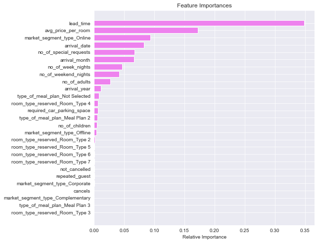

```python
feature_names = list(x1_train.columns)
importances = dTree.feature_importances_
indices = np.argsort(importances)

plt.figure(figsize=(8, 8))
plt.title("Feature Importances")
plt.barh(range(len(indices)), importances[indices], color="violet", align="center")
plt.yticks(range(len(indices)), [feature_names[i] for i in indices])
plt.xlabel("Relative Importance")
plt.show()
```

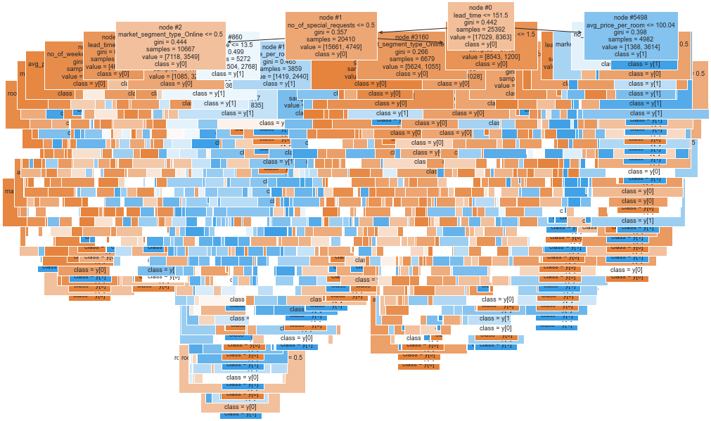

```python
plt.figure(figsize=(15,10))

tree.plot_tree(dTree,feature_names=feature_names,filled=True,fontsize=9,node_ids=True,class_names=True)
plt.show()
```

As you can clearly see in the visual, this tree is obscenely complex and we should be able to significantly prune this to improve performance on the test set relative to training while also reducing complexity.

# Pre-Pruning

```python
# Choose the type of classifier.
estimator = DecisionTreeClassifier(random_state=1, class_weight="balanced")

# Grid of parameters to choose from
parameters = {
    "max_depth": np.arange(2, 7, 2),
    "max_leaf_nodes": [50, 75, 150, 250],
    "min_samples_split": [10, 30, 50, 70]
}

# Type of scoring used to compare parameter combinations
acc_scorer = make_scorer(f1_score)

# Run the grid search
grid_obj = GridSearchCV(estimator, parameters, scoring=acc_scorer, cv=5)
grid_obj = grid_obj.fit(x1_train, y1_train)

# Set the clf to the best combination of parameters
estimator = grid_obj.best_estimator_

# Fit the best algorithm to the data.
estimator.fit(x1_train, y1_train)
```

```
DecisionTreeClassifier(class_weight='balanced', max_depth=6, max_leaf_nodes=50,
                       min_samples_split=10, random_state=1)
```

```python
dTree1 = DecisionTreeClassifier(class_weight='balanced',max_depth=6, max_leaf_nodes=50,min_samples_split=10,random_state=1)
dTree1.fit(x1_train, y1_train)
```

```
DecisionTreeClassifier(class_weight='balanced', max_depth=6, max_leaf_nodes=50,
                       min_samples_split=10, random_state=1)
```

```python
decision_tree_perf_train
```

|  | Accuracy | Recall | Precision | F1 |
| --- | --- | --- | --- | --- |
| 0 | 0.99421 | 0.98661 | 0.99578 | 0.99117 |

```python
decision_tree_tune_perf_train = model_performance_classification_sklearn(dTree1, x1_train, y1_train)
decision_tree_tune_perf_train
```

|  | Accuracy | Recall | Precision | F1 |
| --- | --- | --- | --- | --- |
| 0 | 0.83089 | 0.78620 | 0.72404 | 0.75384 |

```python
decision_tree_perf_test
```

|  | Accuracy | Recall | Precision | F1 |
| --- | --- | --- | --- | --- |
| 0 | 0.86961 | 0.80806 | 0.79298 | 0.80045 |

```python
decision_tree_tune_perf_test = model_performance_classification_sklearn(dTree1, x1_test, y1_test)
decision_tree_tune_perf_test
```

|  | Accuracy | Recall | Precision | F1 |
| --- | --- | --- | --- | --- |
| 0 | 0.83497 | 0.78336 | 0.72758 | 0.75444 |

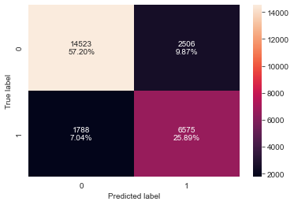

```python
confusion_matrix_sklearn(dTree1, x1_train, y1_train)
```

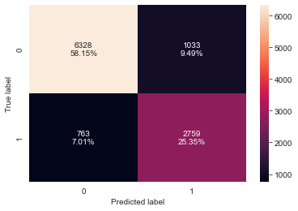

```python
confusion_matrix_sklearn(dTree1, x1_test, y1_test)
```

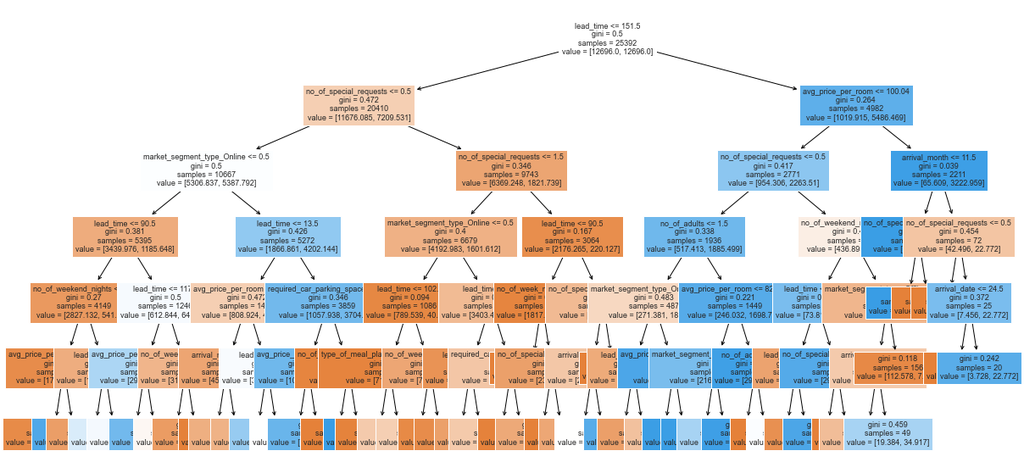

```python
plt.figure(figsize=(20, 10))
out = tree.plot_tree(
    dTree1,
    feature_names=feature_names,
    filled=True,
    fontsize=9,
    node_ids=False,
    class_names=None,
)
# below code will add arrows to the decision tree split if they are missing
for o in out:
    arrow = o.arrow_patch
    if arrow is not None:
        arrow.set_edgecolor("black")
        arrow.set_linewidth(1)
plt.show()
```

# Cost-Complexity Pruning

```python
clf = DecisionTreeClassifier(random_state=1, class_weight="balanced")
path = clf.cost_complexity_pruning_path(x1_train, y1_train)
ccp_alphas, impurities = abs(path.ccp_alphas), path.impurities
```

```python
pd.DataFrame(path)
```

|  | ccp_alphas | impurities |
| --- | --- | --- |
| 0 | 0.00000 | 0.00838 |
| 1 | 0.00000 | 0.00838 |
| 2 | 0.00000 | 0.00838 |
| 3 | 0.00000 | 0.00838 |
| 4 | 0.00000 | 0.00838 |
| ... | ... | ... |
| 1916 | 0.00890 | 0.32806 |
| 1917 | 0.00980 | 0.33786 |
| 1918 | 0.01272 | 0.35058 |
| 1919 | 0.03412 | 0.41882 |
| 1920 | 0.08118 | 0.50000 |

1921 rows × 2 columns

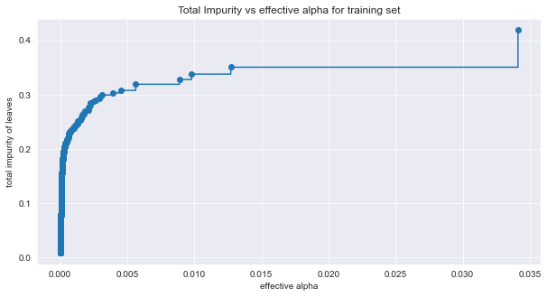

```python
fig, ax = plt.subplots(figsize=(10, 5))
ax.plot(ccp_alphas[:-1], impurities[:-1], marker="o", drawstyle="steps-post")
ax.set_xlabel("effective alpha")
ax.set_ylabel("total impurity of leaves")
ax.set_title("Total Impurity vs effective alpha for training set")
plt.show()
```

```python
clfs = []
for ccp_alpha in ccp_alphas:
    clf = DecisionTreeClassifier(
        random_state=1, ccp_alpha=ccp_alpha, class_weight="balanced"
    )
    clf.fit(x1_train, y1_train)
    clfs.append(clf)

print("Number of nodes in the last tree is: {} with ccp_alpha: {}".format(
      clfs[-1].tree_.node_count, ccp_alphas[-1]))
```

```
Number of nodes in the last tree is: 1 with ccp_alpha: 0.08117914389136938
```

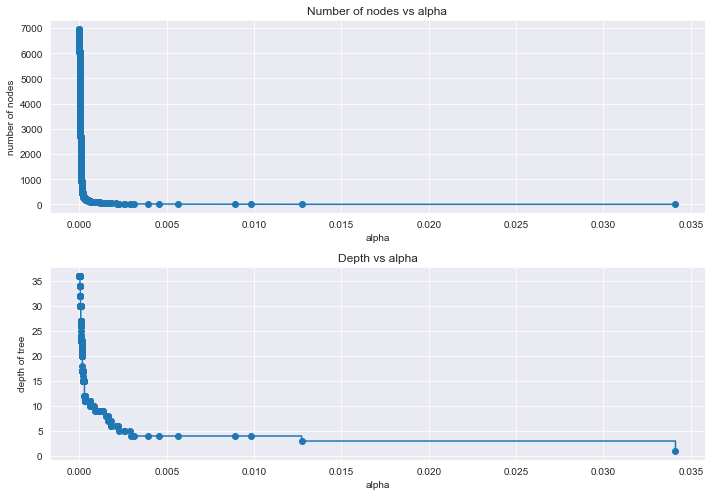

```python
clfs = clfs[:-1]
ccp_alphas = ccp_alphas[:-1]

node_counts = [clf.tree_.node_count for clf in clfs]
depth = [clf.tree_.max_depth for clf in clfs]
fig, ax = plt.subplots(2, 1, figsize=(10, 7))
ax[0].plot(ccp_alphas, node_counts, marker="o", drawstyle="steps-post")
ax[0].set_xlabel("alpha")
ax[0].set_ylabel("number of nodes")
ax[0].set_title("Number of nodes vs alpha")
ax[1].plot(ccp_alphas, depth, marker="o", drawstyle="steps-post")
ax[1].set_xlabel("alpha")
ax[1].set_ylabel("depth of tree")
ax[1].set_title("Depth vs alpha")
fig.tight_layout()
```

```python
f1_train = []
for clf in clfs:
    pred_train = clf.predict(x1_train)
    values_train = f1_score(y1_train, pred_train)
    f1_train.append(values_train)

f1_test = []
for clf in clfs:
    pred_test = clf.predict(x1_test)
    values_test = f1_score(y1_test, pred_test)
    f1_test.append(values_test)
```

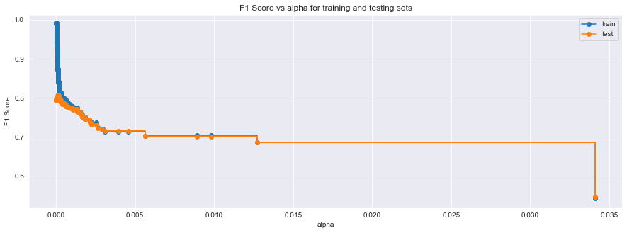

```python
fig, ax = plt.subplots(figsize=(15, 5))
ax.set_xlabel("alpha")
ax.set_ylabel("F1 Score")
ax.set_title("F1 Score vs alpha for training and testing sets")
ax.plot(ccp_alphas, f1_train, marker="o", label="train", drawstyle="steps-post")
ax.plot(ccp_alphas, f1_test, marker="o", label="test", drawstyle="steps-post")
ax.legend()
plt.show()
```

```python
index_best_model = np.argmax(f1_test)
best_model = clfs[index_best_model]
print(best_model)
```

```
DecisionTreeClassifier(ccp_alpha=0.00012291224171537198,
                       class_weight='balanced', random_state=1)
```

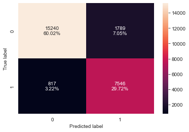

```python
confusion_matrix_sklearn(best_model, x1_train, y1_train)
```

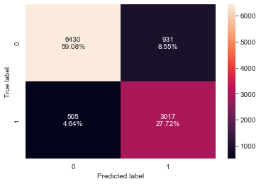

```python
confusion_matrix_sklearn(best_model, x1_test, y1_test)
```

```python
decision_tree_post_perf_train = model_performance_classification_sklearn(best_model, x1_train, y1_train)

decision_tree_post_perf_train
```

|  | Accuracy | Recall | Precision | F1 |
| --- | --- | --- | --- | --- |
| 0 | 0.89737 | 0.90231 | 0.80836 | 0.85275 |

```python
decision_tree_post_perf_test = model_performance_classification_sklearn(best_model, x1_test, y1_test)

decision_tree_post_perf_test
```

|  | Accuracy | Recall | Precision | F1 |
| --- | --- | --- | --- | --- |
| 0 | 0.86805 | 0.85662 | 0.76418 | 0.80776 |

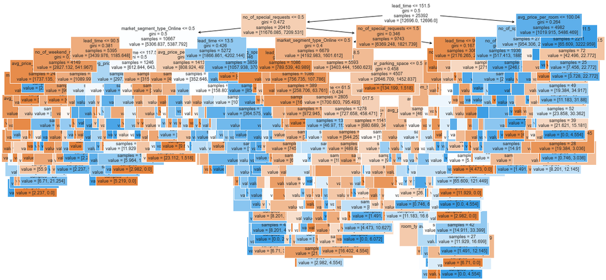

```python
plt.figure(figsize=(20, 10))

out = tree.plot_tree(
    best_model,
    feature_names=feature_names,
    filled=True,
    fontsize=9,
    node_ids=False,
    class_names=None,
)
for o in out:
    arrow = o.arrow_patch
    if arrow is not None:
        arrow.set_edgecolor("black")
        arrow.set_linewidth(1)
plt.show()
```

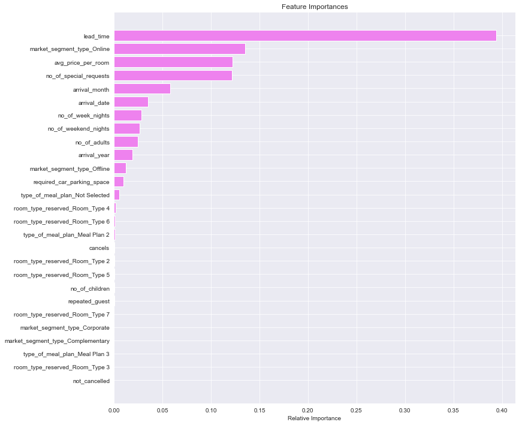

```python
importances = best_model.feature_importances_
indices = np.argsort(importances)

plt.figure(figsize=(12, 12))
plt.title("Feature Importances")
plt.barh(range(len(indices)), importances[indices], color="violet", align="center")
plt.yticks(range(len(indices)), [feature_names[i] for i in indices])
plt.xlabel("Relative Importance")
plt.show()
```